# Modern Data Mining - DSL project

Group Member Matthew Friedman

Group Member Jacob Feigenberg

Group Member Yuting Zhu

Due: 11:59Pm, 4/30, 2023

# Overview

Over the past few years, innovation in fintech has allowed for creative ways for smaller players to make an impact with their capital: platforms like Kickstarter, GoFundMe, and Indiegogo have allowed individuals to make small contributions to business ideas, fundraisers, and other ventures. In 2005, Kiva was founded, using similar technology to allow people to make microloans to businesses and families in developing areas. This method of lending, called microfinance, has drawn supporters for making social impact more accessible for typical individuals and critics for having minimal impact. This study will investigate how loans are made on Kiva, and if these dollars are truly making a difference for people in developing countries.

This project will piggyback off of the homework case study on Lending Club, for we may cite some of the findings or intuitions gained from that study in our analysis of Kiva’s business.

# Methods

We will use extensive EDA to get a sense of the variables in the data. We will explore questions such as which countries or latitude/longitude regions receive the most loans, what is the behavior of common borrowers/lenders on the site, breakdown demographics/gender, etc. We will provide graphics to give evidence for potential answers. We may also identify particularly corrupt or different behavior of loans from a certain MFI partner of Kiva.

We will start with unsupervised machine learning methods like clustering on the data; this will tell us if there are particular patterns that we should further explore in supervised ML methods like regression. We may need to use PCA or apply an L1/L2 penalty to reduce the dimensions of the data if it seems the model is too complex. Maintaining interpretability is important here, since we would like to know how Kiva’s loans are making an impact; thus, we may start with linear regression, so we can draw some insights about some features from their coefficients. Once we gain some insight about the features, we may try more robust methods for prediction, including logistic regression, neural networks, random forests (with/without boosting), or a combination of them all via bagging.

# Data

Main: https://www.kaggle.com/datasets/kiva/data-science-for-good-kiva-crowdfunding?select=kiva_mpi_region_locations.csv

Others: https://www.kaggle.com/code/annalie/metric-for-financial-inclusion/notebook https://www.kaggle.com/datasets/michaelpawlus/tidy-pop-with-access-to-safe-drinking-water https://www.kaggle.com/datasets/gaborfodor/additional-kiva-snapshot?select=lenders.csv https://www.kaggle.com/datasets/sudalairajkumar/undata-country-profiles https://www.kaggle.com/datasets/reubencpereira/spatial-data-repo?select=kivaData_augmented_sample.csv https://www.kaggle.com/datasets/taniaj/gender-development-inequality

# EDA

Data Loading

```r
loans_pre_merge <- read.csv("~/Downloads/final/kiva_loans.csv")
locations <- read.csv("~/Downloads/final/kiva_mpi_region_locations.csv")
themes <- read.csv("~/Downloads/final/loan_theme_ids.csv")
themes_by_region <- read.csv("~/Downloads/final/loan_themes_by_region.csv")

kivacountry <- fread("~/Downloads/final/kiva_country_profile_variables.csv")
genderdevdataset <- fread("~/Downloads/final/gender_development_index.csv")
genderineqdataset <- fread("~/Downloads/final/gender_inequality_index.csv", header = TRUE)
```

The data are all found on Kaggle.

Joining

```r
loans <- merge(themes, loans_pre_merge, by = "id", all = FALSE)
```

We can note that two of these datasets have common, unique IDs. We were able to easily merge these by ID.

```r
#merge loans with locations

loan_locations <- loans %>%
  select(country, funded_amount, loan_amount, term_in_months) %>%
  group_by(country) %>%
  summarise(
    avg_funded_amount = mean(funded_amount),
    avg_loan_amount = mean(loan_amount),
    avg_term_in_months = mean(term_in_months)
  ) %>%
  inner_join(locations, by = "country")
```

Maps

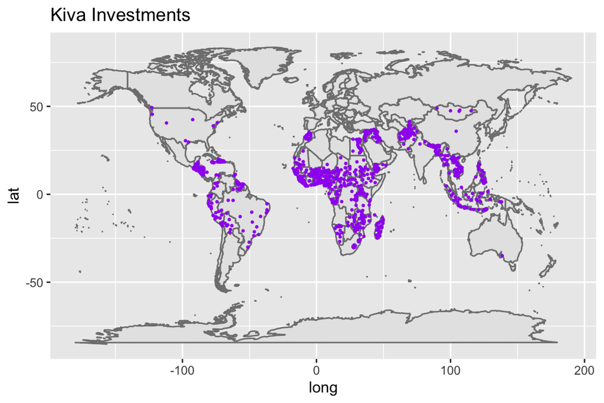

```r
coords <- locations[c("lat", "lon")]
coords <- coords[complete.cases(coords),]

ggplot() +
  borders("world", colour = "gray50", fill = "gray90") +
  geom_point(data = coords, aes(x = lon, y = lat), size = 0.5, color = "purple") +
  ggtitle("Kiva Investments")
```

This map shows the locations of all the loans. We can see the concentration in Africa, Central Asia, and Latin America.

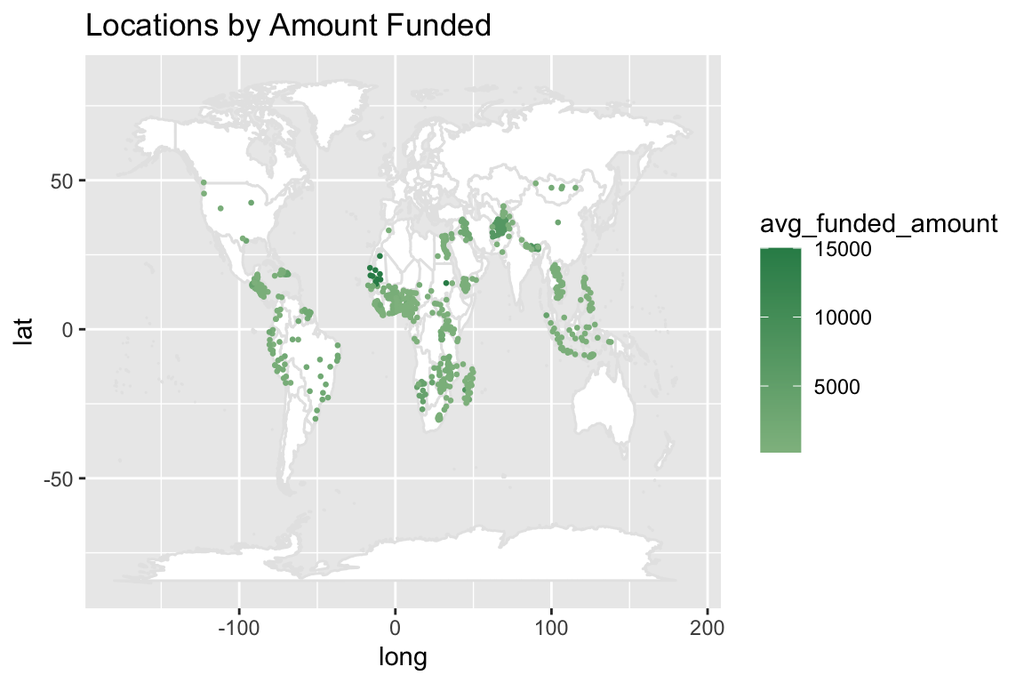

```r
ggplot() +
  borders("world", colour = "gray90", fill = "white") +
  geom_point(data = loan_locations, aes(x = lon, y = lat, col = avg_funded_amount), size = 0.5) + scale_color_gradient(low = "darkseagreen", high = "seagreen") +
  #scale_color_gradient2(midpoint = mean(loan_locations$avg_funded_amount), low="yellow", mid = "red",
#                     high="purple") +
  ggtitle("Locations by Amount Funded")
```

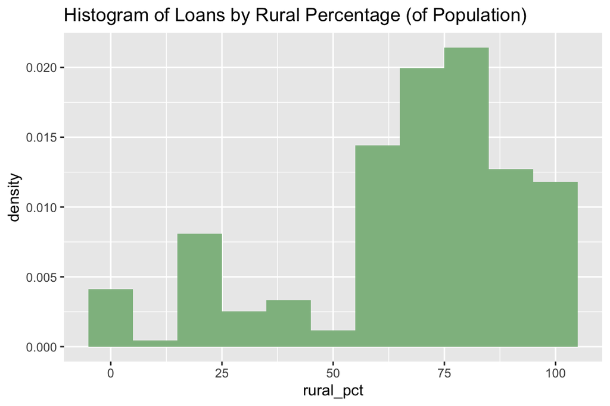

```r
ggplot(data = themes_by_region, aes(x = rural_pct)) +
  geom_histogram(aes(y = ..density..), position = "dodge", binwidth = 10, fill = "darkseagreen") + ggtitle("Histogram of Loans by Rural Percentage (of Population)")
```

This plot shows a primarily rural base of loan recipients.

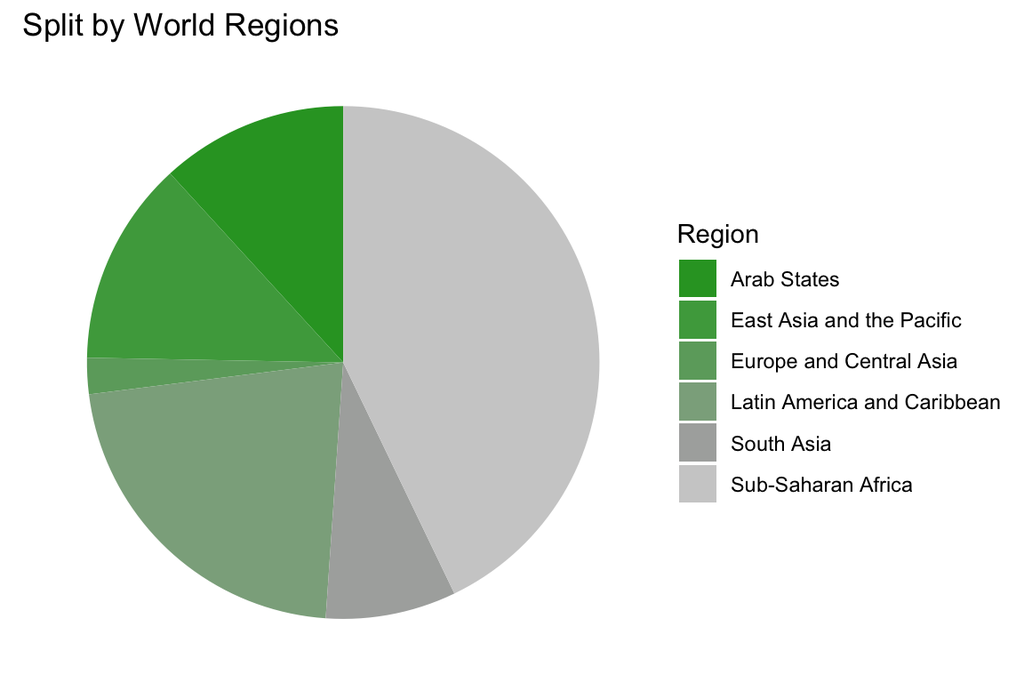

```r
counts <- locations %>%
  group_by(world_region) %>%
  summarize(n = n())

counts <- counts[-1,]

ggplot(counts, aes(x = "", y = n, fill = world_region)) +
  geom_bar(stat = "identity", width = 1) +
  coord_polar("y", start = 0) +
  scale_fill_manual(values = c("#2CA02C", "#4CA64C", "#6CA86C", "#8CAC8C", "#ACAEAC", "#CECECE")) +
  theme_void() +
  labs(fill = "Region", title = "Split by World Regions")
```

This is the split by world regions. We can note that Sub-Saharan Africa is the most popular follows by Latin America and Caribbean.

```r
#select sum funded_amount all from loans group by country order by sum funded amnt limit 10

top_10_countries_df <- loans %>%
  select(country, funded_amount) %>%
  group_by(country) %>%
  summarize(
    funded_amount = sum(funded_amount, na.rm = TRUE)
  ) %>%
  arrange(desc(funded_amount)) %>%
  slice(1:10)
```

```r
#top 10 countries receiving funding from kiva lenders, in aggregate
top_10_countries_df
```

```
## # A tibble: 10 × 2
##    country       funded_amount
##    <chr>                 <dbl>
##  1 Philippines        54476375
##  2 Kenya              32248405
##  3 Peru               30394850
##  4 Paraguay           29412700
##  5 El Salvador        23357725
##  6 United States      23158540
##  7 Cambodia           18817100
##  8 Bolivia            18276200
##  9 Rwanda             15505600
## 10 Ecuador            14598900
```

These are the top 10 countries receiving loans from Kiva lenders.

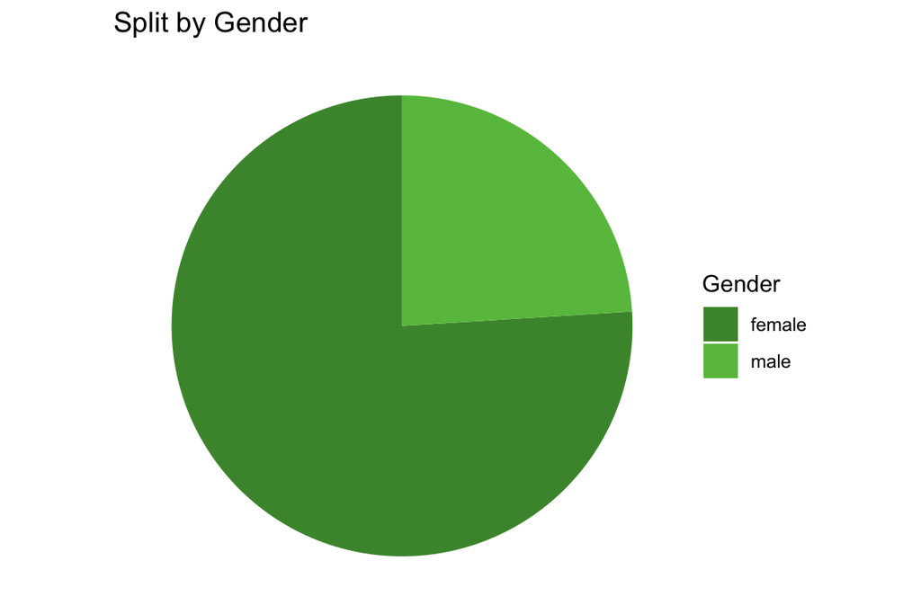

```r
filtered_g <- loans %>%
  filter(borrower_genders %in% c("female", "male"))

counts <- filtered_g %>%
  group_by(borrower_genders) %>%
  summarize(n = n())

ggplot(counts, aes(x = "", y = n, fill = borrower_genders)) +
  geom_bar(stat = "identity", width = 1) +
  coord_polar("y", start = 0) +
  scale_fill_manual(values = c( "#4A9339",  "#66BF4B")) +
  theme_void() +
  labs(fill = "Gender", title = "Split by Gender")
```

Over 75% of loans are given to people who identify as women.

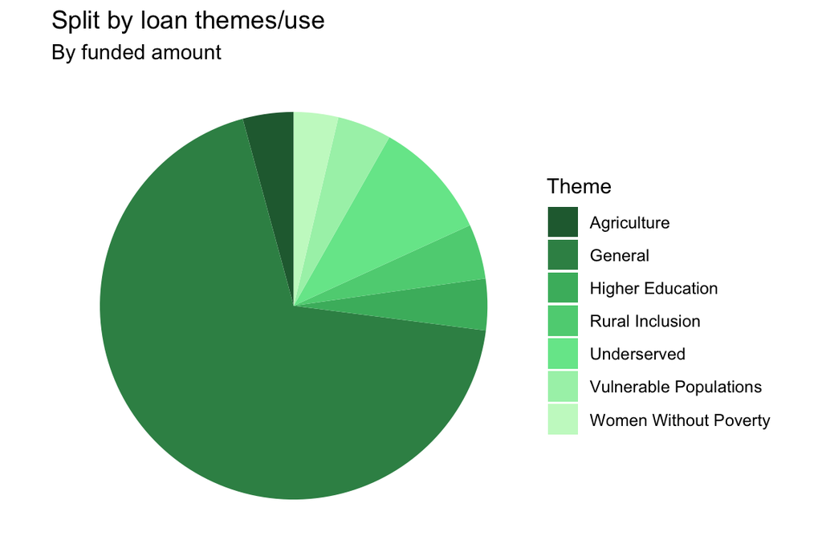

```r
counts <- loans %>%
  group_by(Loan.Theme.Type) %>%
  summarize(n = sum(funded_amount))

filtered_themes <- counts %>%
  filter(n > 10000000)

filtered_themes <- filtered_themes[-1,]

ggplot(filtered_themes, aes(x = "", y = n, fill = Loan.Theme.Type)) +
  geom_bar(stat = "identity", width = 1) +
  coord_polar("y", start = 0) +
  scale_fill_manual(values = c("#24693D", "#368F55", "#47B76D", "#5CD082", "#74E699", "#A7F0B6", "#C7F8CA", "#D9FBE1", "#EDFDF7")) +
  theme_void() +
  labs(fill = "Theme", title = "Split by loan themes/use", subtitle = "By funded amount")
```

In terms of loan themes, they are mostly “General”, but “Underserved” is the second largest group.

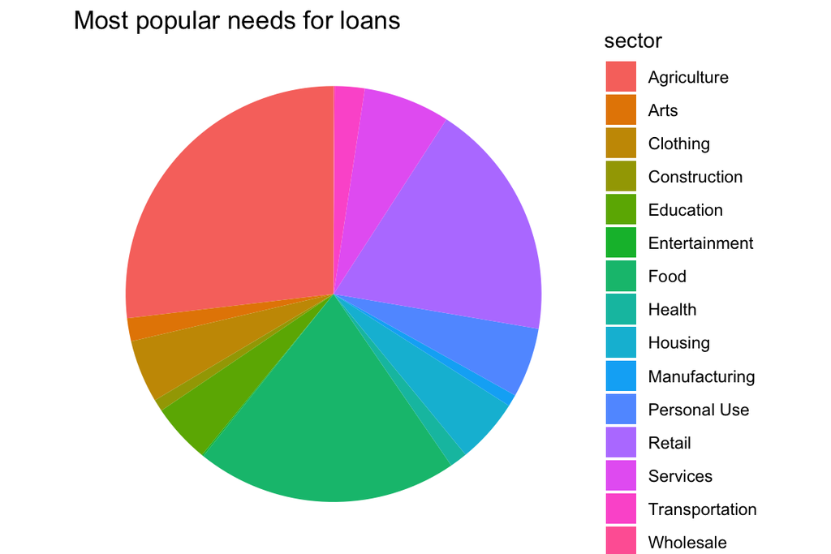

```r
counts <- loans %>%
  group_by(sector) %>%
  summarize(n = n())

ggplot(counts, aes(x = "", y = n, fill = sector)) +
  geom_bar(stat = "identity", width = 1) +
  coord_polar("y", start = 0) +
  theme_void() +
  labs(fill = "sector", title = "Most popular needs for loans")
```

```r
loans %>% group_by(Loan.Theme.Type) %>% summarise(n = sum(loan_amount)) %>%
  arrange(-n)
```

```
## # A tibble: 198 × 2
##    Loan.Theme.Type                  n
##    <chr>                        <dbl>
##  1 "General"                260493425
##  2 "Underserved"             37733925
##  3 ""                        28566500
##  4 "Rural Inclusion"         18372725
##  5 "Vulnerable Populations"  17442050
##  6 "Agriculture"             16601275
##  7 "Higher Education"        16026425
##  8 "Women Without Poverty"   13444850
##  9 "Startup"                 10671550
## 10 "General (Women)"          9872400
## # ℹ 188 more rows
```

```r
loans %>% filter(Loan.Theme.Type == "Underserved") %>% group_by(sector) %>%
  summarise(n = sum(loan_amount), type = "Underserved") %>% arrange(-n)
```

```
## # A tibble: 15 × 3
##    sector                n type
##    <chr>             <dbl> <chr>
##  1 Agriculture    13634800 Underserved
##  2 Food            8166275 Underserved
##  3 Retail          5542550 Underserved
##  4 Services        2610875 Underserved
##  5 Arts            1681325 Underserved
##  6 Transportation  1679900 Underserved
##  7 Clothing        1515925 Underserved
##  8 Housing          739150 Underserved
##  9 Manufacturing    591475 Underserved
## 10 Construction     419350 Underserved
## 11 Health           402575 Underserved
## 12 Education        384125 Underserved
## 13 Personal Use     227200 Underserved
## 14 Wholesale         74175 Underserved
## 15 Entertainment     64225 Underserved
```

```r
loans %>% filter(Loan.Theme.Type == "General") %>% group_by(sector) %>%
  summarise(n = sum(loan_amount), type = "General") %>% arrange(-n)
```

```
## # A tibble: 15 × 3
##    sector                n type
##    <chr>             <dbl> <chr>
##  1 Food           74328525 General
##  2 Retail         63110025 General
##  3 Agriculture    47509700 General
##  4 Clothing       22937850 General
##  5 Services       19328725 General
##  6 Housing         6718050 General
##  7 Arts            5881475 General
##  8 Transportation  5424575 General
##  9 Construction    3558000 General
## 10 Personal Use    3256375 General
## 11 Health          2913075 General
## 12 Manufacturing   2899250 General
## 13 Education       1991725 General
## 14 Entertainment    349775 General
## 15 Wholesale        286300 General
```

This chunk is to explore the loan types which receive the most loan_amounts in the dataset loans (loans <- merge(themes, loans_pre_merge, by = “id”, all = FALSE)

And also seeing what are the specific sectors are the loans that are categorized as “General” and “Underserved”

[output not shown]

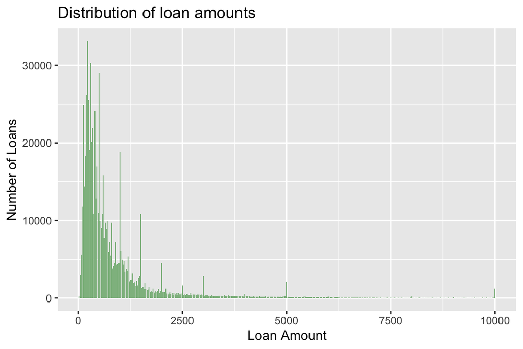

```r
filtered_loans <- loans %>%
  filter(loan_amount <= 10000)

filtered_loans <- filtered_loans %>%
  group_by(loan_amount) %>%
  summarize(n = n())

ggplot(filtered_loans, aes(x = loan_amount, y = n)) +
  geom_bar(stat = "identity", fill = "darkseagreen") +
  labs(x = "Loan Amount", y = "Number of Loans", title = "Distribution of loan amounts")
```

Most loans are in the hundreds of US Dollars, but some go as high as $10,000.

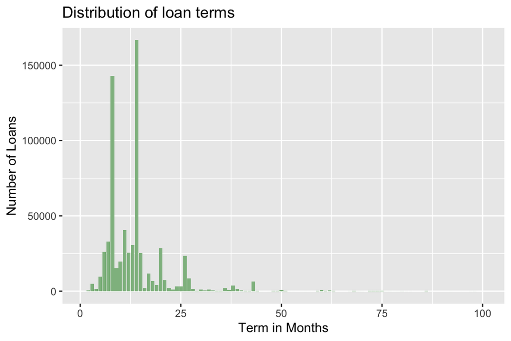

```r
filtered_values <- loans %>%
  filter(term_in_months <= 100)

filtered_values <- filtered_values %>%
  group_by(term_in_months) %>%
  summarize(n = n())

ggplot(filtered_values, aes(x = term_in_months, y = n)) +
  geom_bar(stat = "identity", fill = "darkseagreen") +
  labs(x = "Term in Months", y = "Number of Loans", title = "Distribution of loan terms")
```

Many loans also have terms of less than 2 years with some outliers.

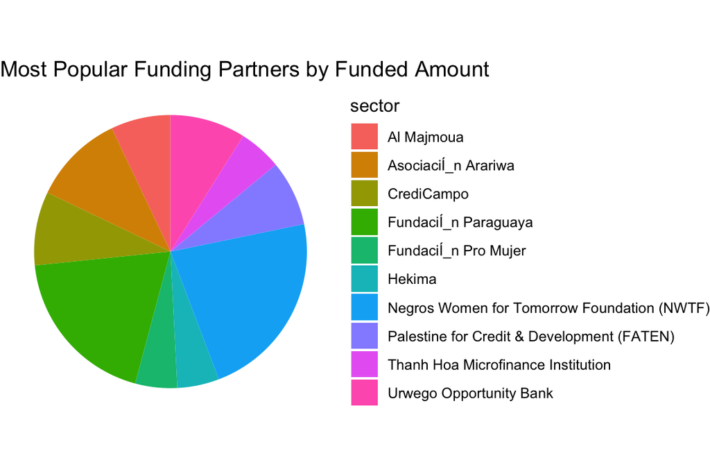

```r
counts <- themes_by_region %>%
  group_by(Field.Partner.Name) %>%
  summarize(n = sum(amount))

counts_filtered <- counts %>%
  filter(n > 5000000)

ggplot(counts_filtered, aes(x = "", y = n, fill = Field.Partner.Name)) +
  geom_bar(stat = "identity", width = 1) +
  coord_polar("y", start = 0) +
  theme_void() +
  labs(fill = "sector", title = "Most Popular Funding Partners by Funded Amount")
```

```r
counts_bar <- counts %>%
  filter(n > 5000000)
```

Finding highest lending partners by percentage of total loan value

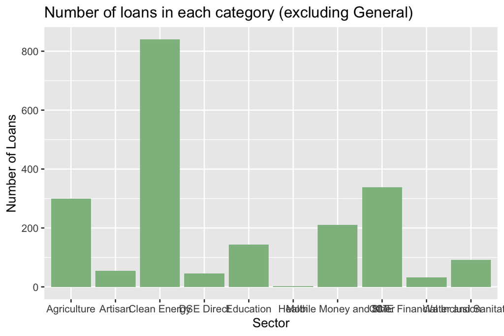

```r
counts_themes <- themes_by_region %>%
  group_by(sector) %>%
  summarize(n = n())

counts_themes <- subset(counts_themes, sector != "General Financial Inclusion")

ggplot(counts_themes, aes(x = sector, y = n)) +
  geom_bar(stat = "identity", fill = "darkseagreen") +
  labs(x = "Sector", y = "Number of Loans", title = "Number of loans in each category (excluding General)")
```

Split by category (on the total number of loans).

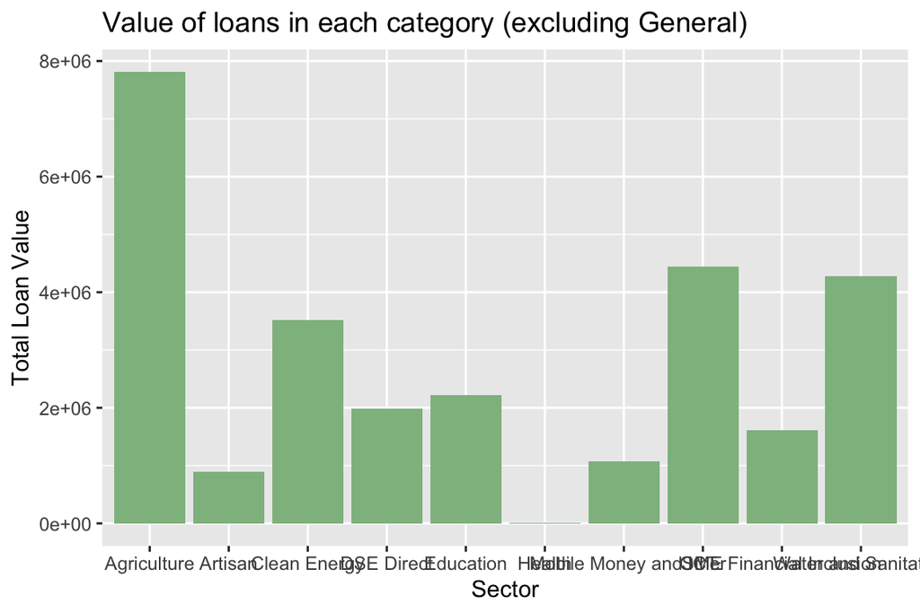

```r
counts_themes <- themes_by_region %>%
  group_by(sector) %>%
  summarize(n = sum(amount))

counts_themes <- subset(counts_themes, sector != "General Financial Inclusion")

ggplot(counts_themes, aes(x = sector, y = n)) +
  geom_bar(stat = "identity", fill = "darkseagreen") +
  labs(x = "Sector", y = "Total Loan Value", title = "Value of loans in each category (excluding General)")
```

Split by category (on the value of loans). We can see agriculture has disproportionately high loan values while Clean Energy is much lower.

This chunk is to explore the specific sectors of the loans that are categorized as “General” and “Underserved” (the most popular two types of loans by amount)

```r
loans %>% filter(Loan.Theme.Type == "Underserved") %>% group_by(sector) %>%
  summarise(n = sum(loan_amount), type = "Underserved") %>% arrange(-n)
```

```
## # A tibble: 15 × 3
##    sector                n type
##    <chr>             <dbl> <chr>
##  1 Agriculture    13634800 Underserved
##  2 Food            8166275 Underserved
##  3 Retail          5542550 Underserved
##  4 Services        2610875 Underserved
##  5 Arts            1681325 Underserved
##  6 Transportation  1679900 Underserved
##  7 Clothing        1515925 Underserved
##  8 Housing          739150 Underserved
##  9 Manufacturing    591475 Underserved
## 10 Construction     419350 Underserved
## 11 Health           402575 Underserved
## 12 Education        384125 Underserved
## 13 Personal Use     227200 Underserved
## 14 Wholesale         74175 Underserved
## 15 Entertainment     64225 Underserved
```

```r
loans %>% filter(Loan.Theme.Type == "General") %>% group_by(sector) %>%
  summarise(n = sum(loan_amount), type = "General") %>% arrange(-n)
```

```
## # A tibble: 15 × 3
##    sector                n type
##    <chr>             <dbl> <chr>
##  1 Food           74328525 General
##  2 Retail         63110025 General
##  3 Agriculture    47509700 General
##  4 Clothing       22937850 General
##  5 Services       19328725 General
##  6 Housing         6718050 General
##  7 Arts            5881475 General
##  8 Transportation  5424575 General
##  9 Construction    3558000 General
## 10 Personal Use    3256375 General
## 11 Health          2913075 General
## 12 Manufacturing   2899250 General
## 13 Education       1991725 General
## 14 Entertainment    349775 General
## 15 Wholesale        286300 General
```

[output not shown]

Read in the UN country profile dataset

EDA of UN country profile dataset and merge this dataset with the cleaned loans dataset, the merged dataset is called merged1, after checking, it has no null values

```r
loans_omitna <- na.omit(loans)
loans_omitna <- loans %>% na.omit(loans) %>%
  filter(region != "", country != "")

agre_loans <- loans_omitna %>%
  select(country, region, loan_amount, Loan.Theme.Type, sector) %>%
  group_by(country, region) %>% summarise(n = sum(loan_amount))
agre_loans_country <- agre_loans %>% select(country, n) %>%
  group_by(country) %>% summarise(loan_amount = sum(n))


merged1 <- merge(agre_loans_country, kivacountry, by = "country", all = FALSE)
merged1_omit <- na.omit(merged1)
```

Read in two other files that have countries’ gender indexes, take the year of 2013, to be consistent with the existing datasets.

```r
genderdevdataset_clean_2013 <- genderdevdataset %>% select(
                                                           Country, `2013`) %>%
  na.omit %>% mutate(country = Country,
                     dev2013 = `2013`) %>% select(-Country, -`2013`)


genderineqdataset_clean_2013 <- genderineqdataset %>% select(
                                                           Country, `2013`) %>%
  na.omit %>% mutate(country = Country,
                     ineq2013 = `2013`) %>% select(-Country, -`2013`)
```

Datacleaning of gender data, merge merged1 with gender data, call it merged2

```r
gendermerged <- merge(genderdevdataset_clean_2013,
                      genderineqdataset_clean_2013, by = "country",
                      all = FALSE)
head(gendermerged)
merged2 <- merge(gendermerged, merged1, by = "country", all = FALSE )
dim(merged2)
```

Clean Merged2: turn incorrect character variables into numeric

```r
country_list <- merged2$country
merged2 <-  merged2 %>% select(-Region, -country) %>% mutate_if(is.character, as.numeric)
sapply(merged2, class)
```

```
##                                                    dev2013
##                                                  "numeric"
##                                                   ineq2013
##                                                  "numeric"
##                                                loan_amount
##                                                  "numeric"
##                                         Surface area (km2)
##                                                  "integer"
##                             Population in thousands (2017)
##                                                  "integer"
##                         Population density (per km2, 2017)
##                                                  "numeric"
##                              Sex ratio (m per 100 f, 2017)
##                                                  "numeric"
##          GDP: Gross domestic product (million current US$)
##                                                  "integer"
##             GDP growth rate (annual %, const. 2005 prices)
##                                                  "numeric"
##                               GDP per capita (current US$)
##                                                  "numeric"
##                            Economy: Agriculture (% of GVA)
##                                                  "numeric"
##                               Economy: Industry (% of GVA)
##                                                  "numeric"
##            Economy: Services and other activity (% of GVA)
##                                                  "numeric"
##                    Employment: Agriculture (% of employed)
##                                                  "numeric"
##                       Employment: Industry (% of employed)
##                                                  "numeric"
##                       Employment: Services (% of employed)
##                                                  "numeric"
##                           Unemployment (% of labour force)
##                                                  "numeric"
##            Labour force participation (female/male pop. %)
##                                                  "numeric"
##              Agricultural production index (2004-2006=100)
##                                                  "integer"
##                      Food production index (2004-2006=100)
##                                                  "integer"
```

[output cut: 47 more lines]

```
##                                                  "numeric"
##                             Forested area (% of land area)
##                                                  "numeric"
##      CO2 emission estimates (million tons/tons per capita)
##                                                  "integer"
##                    Energy production, primary (Petajoules)
##                                                  "integer"
##                      Energy supply per capita (Gigajoules)
##                                                  "numeric"
##        Pop. using improved drinking water (urban/rural, %)
##                                                  "numeric"
## Pop. using improved sanitation facilities (urban/rural, %)
##                                                  "numeric"
##       Net Official Development Assist. received (% of GNI)
##                                                  "integer"
```

```r
merged2 <- cbind(country_list, merged2)
merged2 <- merged2 %>% mutate(country = country_list) %>% select(-country_list)
```

# PCA

Before doing PCAs, kick out the variables that have no variance (zero_var_cols)

```r
sd_values <- merged2 %>% summarise_all(sd)
zero_var_cols <- names(sd_values)[sd_values == 0]
merged2 <- merged2 %>% select(-`Net Official Development Assist. received (% of GNI)`,
                             - `Life expectancy at birth (females/males, years)`,
                            - `Population age distribution (0-14 / 60+ years, %)`,
                            -`Labour force participation (female/male pop. %)`,
                            - `Balance of payments, current account (million US$)`,
                            - `International migrant stock (000/% of total pop.)`,
                            - `Refugees and others of concern to UNHCR (in thousands)`,
                            - `Health: Physicians (per 1000 pop.)`,
                            - `Education: Government expenditure (% of GDP)`,
                            - `Education: Primary gross enrol. ratio (f/m per 100 pop.)`,
                            - `Education: Secondary gross enrol. ratio (f/m per 100 pop.)`,
                            - `Education: Tertiary gross enrol. ratio (f/m per 100 pop.)`,
                            - `Energy supply per capita (Gigajoules)`,
                            - `Pop. using improved drinking water (urban/rural, %)`,
                            - `Forested area (% of land area)`)
```

# Clustering

Kmeans clustering! Chose 4 clusters

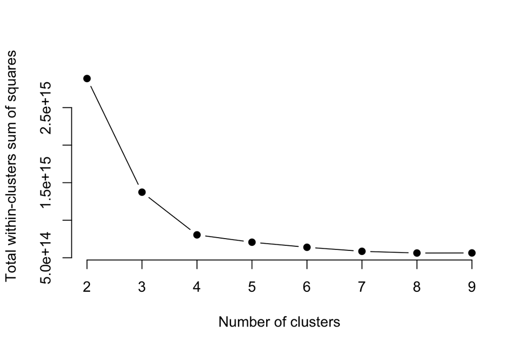

```r
wss <- function(df, k) {
  kmeans(df, k, nstart = 10)$tot.withinss
}
k.values <- 2:9
wss.values <- sapply(k.values, function(k) kmeans(merged2[,-37], centers = k)$
                       tot.withinss)
plot(k.values, wss.values, type = "b", pch = 19, frame = FALSE,
     xlab = "Number of clusters", ylab = "Total within-clusters sum of squares")
```

PCA analysis: choose 2 PCs for easiness of interpretation

```r
kivacountry.pca <- prcomp(merged2 %>% select(-country), scale = T)
kivacountry_cluster <- kmeans(kivacountry.pca$x[, 1:2], centers = 4)
```

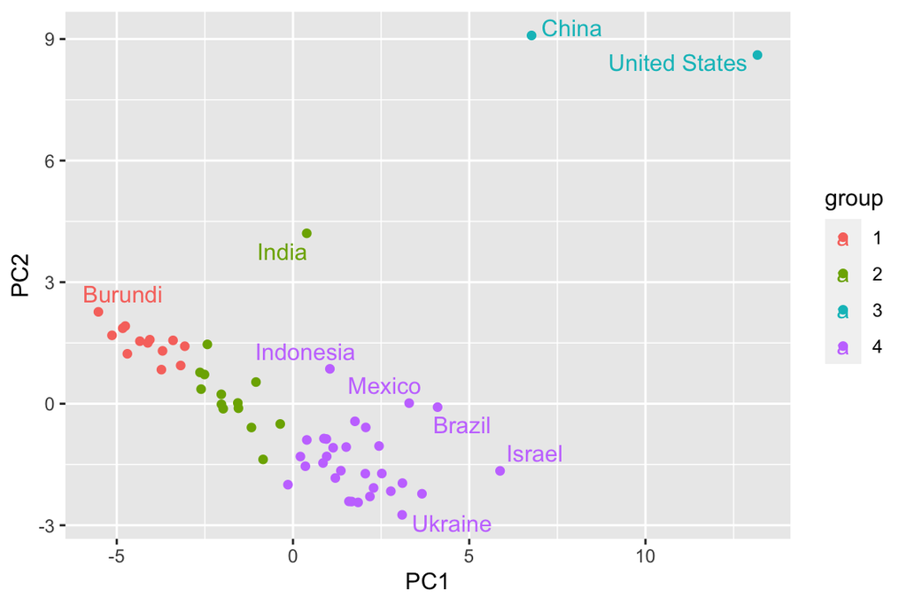

```r
data.frame(country = merged2$country,
           PC1 = kivacountry.pca$x[, 1],
           PC2 = kivacountry.pca$x[, 2],
           group = as.factor(kivacountry_cluster$cluster)) %>%
  ggplot(aes(x= PC1, y = PC2, col = group)) +
  geom_point() +
  ggrepel::geom_text_repel(aes(label = country),
                           max.overlaps = 11)
```

```r
kivacountry.pca$rotation[,1:2]
```

```
##                                                                     PC1
## dev2013                                                     0.166688226
## ineq2013                                                   -0.227073230
## loan_amount                                                 0.005319006
## Surface area (km2)                                          0.174863760
## Population in thousands (2017)                              0.091594709
## Population density (per km2, 2017)                         -0.016104930
## Sex ratio (m per 100 f, 2017)                              -0.033099149
## GDP: Gross domestic product (million current US$)           0.184602585
## GDP growth rate (annual %, const. 2005 prices)              0.026721293
## GDP per capita (current US$)                                0.229265321
## Economy: Agriculture (% of GVA)                            -0.212634855
## Economy: Industry (% of GVA)                                0.061451304
## Economy: Services and other activity (% of GVA)             0.186413549
## Employment: Agriculture (% of employed)                    -0.244061844
## Employment: Industry (% of employed)                        0.197625642
## Employment: Services (% of employed)                        0.236989454
## Unemployment (% of labour force)                            0.031845751
## Agricultural production index (2004-2006=100)              -0.073306516
## Food production index (2004-2006=100)                      -0.082332057
## International trade: Exports (million US$)                  0.170886205
## International trade: Imports (million US$)                  0.188966683
## International trade: Balance (million US$)                 -0.082861964
## Population growth rate (average annual %)                  -0.151424571
## Urban population (% of total population)                    0.223369794
## Urban population growth rate (average annual %)            -0.202560232
## Fertility rate, total (live births per woman)              -0.234686136
## Infant mortality rate (per 1000 live births                -0.248494779
## Health: Total expenditure (% of GDP)                        0.017271327
## Seats held by women in national parliaments %              -0.015965391
## Mobile-cellular subscriptions (per 100 inhabitants)         0.169238383
## Mobile-cellular subscriptions (per 100 inhabitants).1       0.243147640
## Individuals using the Internet (per 100 inhabitants)        0.140829795
## Threatened species (number)                                 0.015792116
## CO2 emission estimates (million tons/tons per capita)       0.171201352
## Energy production, primary (Petajoules)                     0.245545037
## Pop. using improved sanitation facilities (urban/rural, %) -0.201983093
##                                                                     PC2
## dev2013                                                    -0.145916714
## ineq2013                                                    0.039553867
```

[output cut: 19 more lines]

```
## International trade: Balance (million US$)                 -0.060011467
## Population growth rate (average annual %)                   0.051384471
## Urban population (% of total population)                   -0.146681717
## Urban population growth rate (average annual %)             0.161842819
## Fertility rate, total (live births per woman)               0.118183647
## Infant mortality rate (per 1000 live births                 0.150576219
## Health: Total expenditure (% of GDP)                        0.064570287
## Seats held by women in national parliaments %              -0.001301199
## Mobile-cellular subscriptions (per 100 inhabitants)        -0.204037389
## Mobile-cellular subscriptions (per 100 inhabitants).1      -0.105159494
## Individuals using the Internet (per 100 inhabitants)        0.161824196
## Threatened species (number)                                -0.015355513
## CO2 emission estimates (million tons/tons per capita)       0.339947366
## Energy production, primary (Petajoules)                     0.103223732
## Pop. using improved sanitation facilities (urban/rural, %) -0.076493274
```

# Lasso attempts

Lasso to select variables that are more important in explaining the loan_amounts by country. Using set.seed(10), Lasso couldn’t find proper variables.

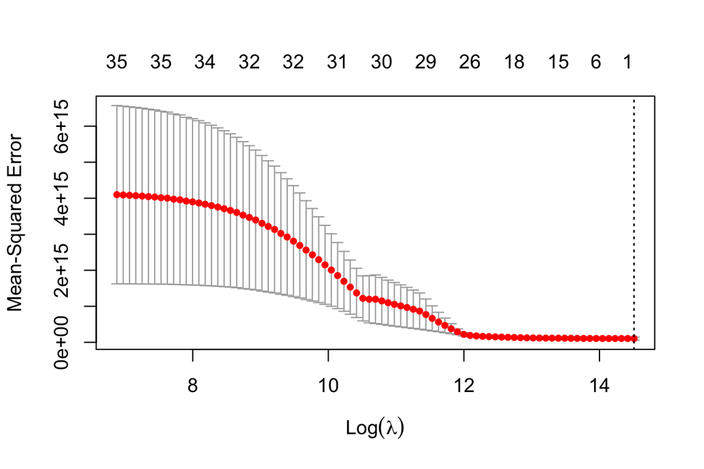

```r
merged2 <- as.data.frame(merged2)
loan_amountasY <- merged2[, 3]
merged2.X <- model.matrix(loan_amount~(.-country), data = merged2)[,-1]
set.seed(10)
fitcountryvseverythingelse <- cv.glmnet(merged2.X, loan_amountasY, alpha = 1,
                                        nfolds = 10, intercept = T)
coef.min <- coef(fitcountryvseverythingelse, s = "lambda.min")
plot(fitcountryvseverythingelse)
```

```r
coef.min <- coef.min[which(coef.min != 0),]
var.min <- rownames(as.matrix(coef.min))[-1]
var.min
```

Using set.seed(20), Lasso didn’t find significant variables at 0.01 level

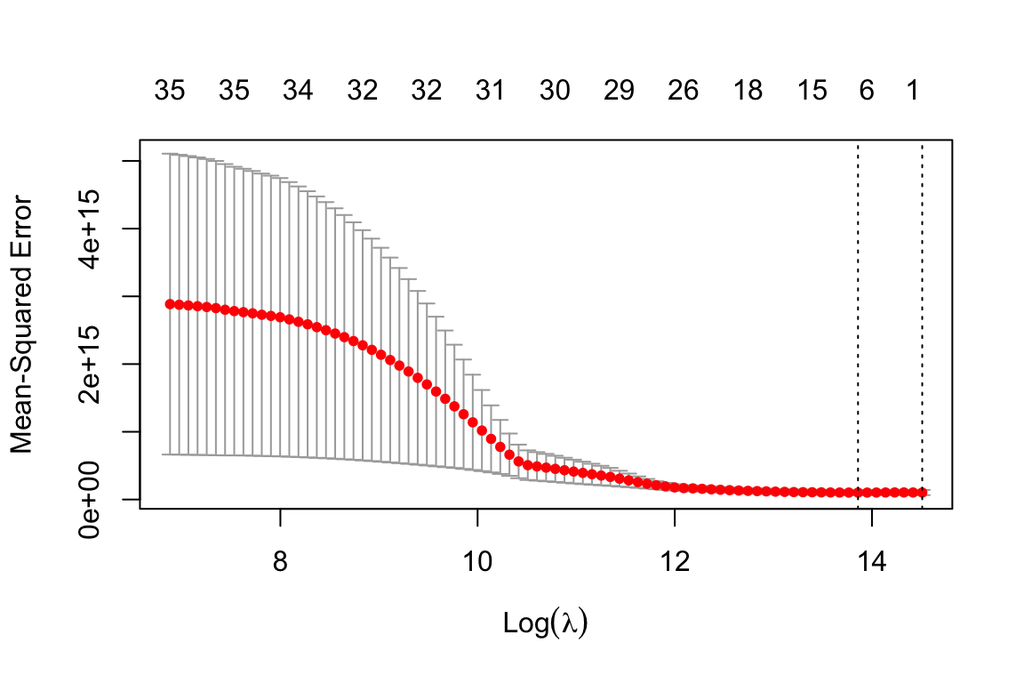

```r
set.seed(20)
fitcountryvseverythingelse <- cv.glmnet(merged2.X, loan_amountasY, alpha = 1,
                                        nfolds = 10, intercept = T)
coef.min <- coef(fitcountryvseverythingelse, s = "lambda.min")
plot(fitcountryvseverythingelse)
```

```r
coef.min <- coef.min[which(coef.min != 0),]
var.min <- rownames(as.matrix(coef.min))[-1]
var.min
```

```
## [1] "`Population density (per km2, 2017)`"
## [2] "`GDP growth rate (annual %, const. 2005 prices)`"
## [3] "`Unemployment (% of labour force)`"
## [4] "`Urban population growth rate (average annual %)`"
## [5] "`Individuals using the Internet (per 100 inhabitants)`"
## [6] "`Energy production, primary (Petajoules)`"
```

```r
lm.input <- as.formula(paste("loan_amount", "~", paste(var.min, collapse = "+")))
Kivalm <- lm(lm.input, data=merged2) # debiased or relaxed LASSO
summary(Kivalm)
```

```
##
## Call:
## lm(formula = lm.input, data = merged2)
##
## Residuals:
##       Min        1Q    Median        3Q       Max
## -12260848  -5096478  -2803213   2048725  36493070
##
## Coefficients:
##                                                        Estimate Std. Error
## (Intercept)                                            14840054    4690451
## `Population density (per km2, 2017)`                      12850       9911
## `GDP growth rate (annual %, const. 2005 prices)`         243500     209520
## `Unemployment (% of labour force)`                      -193101     212234
## `Urban population growth rate (average annual %)`      -2529411    1012860
## `Individuals using the Internet (per 100 inhabitants)`     5268       3004
## `Energy production, primary (Petajoules)`                -88826      33439
##                                                        t value Pr(>|t|)
## (Intercept)                                              3.164   0.0026 **
## `Population density (per km2, 2017)`                     1.296   0.2005
## `GDP growth rate (annual %, const. 2005 prices)`         1.162   0.2505
## `Unemployment (% of labour force)`                      -0.910   0.3671
## `Urban population growth rate (average annual %)`       -2.497   0.0157 *
## `Individuals using the Internet (per 100 inhabitants)`   1.753   0.0854 .
## `Energy production, primary (Petajoules)`               -2.656   0.0105 *
## ---
## Signif. codes:  0 '***' 0.001 '**' 0.01 '*' 0.05 '.' 0.1 ' ' 1
##
## Residual standard error: 9330000 on 52 degrees of freedom
## Multiple R-squared:  0.233,  Adjusted R-squared:  0.1445
## F-statistic: 2.633 on 6 and 52 DF,  p-value: 0.0264
```

# Regression Subset

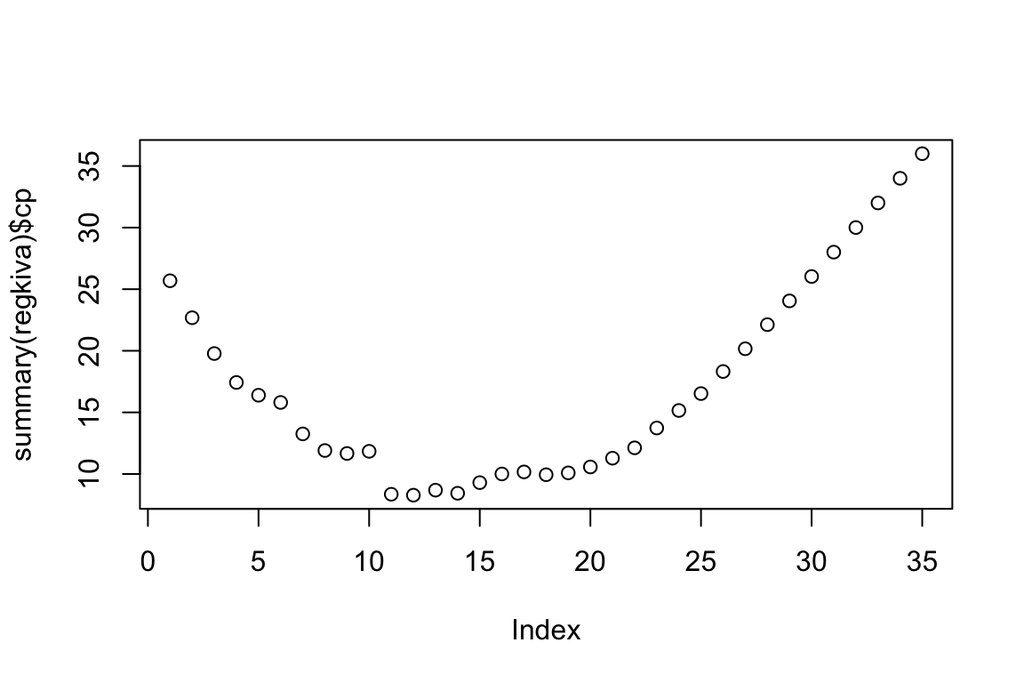

```r
regkiva <- regsubsets(loan_amount~(.-country), nvmax = 35, method = "exhau",
                      merged2)
plot(summary(regkiva)$cp)
```

```r
regkiva.1.s <- summary(regkiva)
opt.size <- 11
regkiva.var.1 <- regkiva.1.s$which
var.min.reg <- colnames(regkiva.var.1)[regkiva.var.1[opt.size, ]][-1]

regkivareduced <- lm(loan_amount ~`GDP per capita (current US$)` +
                       `Economy: Agriculture (% of GVA)` +
                       `Employment: Agriculture (% of employed)` +
                       `Employment: Industry (% of employed)` +
                       `Employment: Services (% of employed)` +
`International trade: Imports (million US$)` +
`Mobile-cellular subscriptions (per 100 inhabitants).1` +
`Individuals using the Internet (per 100 inhabitants)` +
`CO2 emission estimates (million tons/tons per capita)` +
`Energy production, primary (Petajoules)` +
`Pop. using improved sanitation facilities (urban/rural, %)`, merged2)
```

# Exploring model fitting

See a summary of the model and see how well the model explains the loan_amount. We spotted some large residuals. 43 and 44 are Peru and Philippines. They receive much more loans than other countries so the model doesn’t explain them well. Explore 54, Uganda, which has many countries that receive similar loans. Why does Uganda fail to fit in the model?

```r
summary(regkivareduced)
```

```
##
## Call:
## lm(formula = loan_amount ~ `GDP per capita (current US$)` + `Economy: Agriculture (% of GVA)` +
##     `Employment: Agriculture (% of employed)` + `Employment: Industry (% of employed)` +
##     `Employment: Services (% of employed)` + `International trade: Imports (million US$)` +
##     `Mobile-cellular subscriptions (per 100 inhabitants).1` +
##     `Individuals using the Internet (per 100 inhabitants)` +
##     `CO2 emission estimates (million tons/tons per capita)` +
##     `Energy production, primary (Petajoules)` + `Pop. using improved sanitation facilities (urban/rural, %)`,
##     data = merged2)
##
## Residuals:
##       Min        1Q    Median        3Q       Max
## -12561813  -4153681   -681723   3368092  25482096
##
## Coefficients:
##                                                                Estimate
## (Intercept)                                                  -7.365e+09
## `GDP per capita (current US$)`                               -1.723e+03
## `Economy: Agriculture (% of GVA)`                             4.128e+05
## `Employment: Agriculture (% of employed)`                     7.355e+07
## `Employment: Industry (% of employed)`                        7.355e+07
## `Employment: Services (% of employed)`                        7.384e+07
## `International trade: Imports (million US$)`                  5.365e+01
## `Mobile-cellular subscriptions (per 100 inhabitants).1`       2.502e+05
## `Individuals using the Internet (per 100 inhabitants)`        7.071e+03
## `CO2 emission estimates (million tons/tons per capita)`      -8.438e+02
## `Energy production, primary (Petajoules)`                    -1.674e+05
## `Pop. using improved sanitation facilities (urban/rural, %)` -5.503e+05
##                                                              Std. Error t value
## (Intercept)                                                   2.312e+09  -3.185
## `GDP per capita (current US$)`                                4.756e+02  -3.623
## `Economy: Agriculture (% of GVA)`                             1.375e+05   3.001
## `Employment: Agriculture (% of employed)`                     2.311e+07   3.183
## `Employment: Industry (% of employed)`                        2.314e+07   3.179
## `Employment: Services (% of employed)`                        2.311e+07   3.195
## `International trade: Imports (million US$)`                  1.568e+01   3.422
## `Mobile-cellular subscriptions (per 100 inhabitants).1`       8.885e+04   2.816
## `Individuals using the Internet (per 100 inhabitants)`        2.900e+03   2.439
## `CO2 emission estimates (million tons/tons per capita)`       2.598e+02  -3.248
## `Energy production, primary (Petajoules)`                     5.777e+04  -2.898
## `Pop. using improved sanitation facilities (urban/rural, %)`  1.357e+05  -4.057
##                                                              Pr(>|t|)
## (Intercept)                                                  0.002568 **
## `GDP per capita (current US$)`                               0.000713 ***
## `Economy: Agriculture (% of GVA)`                            0.004292 **
## `Employment: Agriculture (% of employed)`                    0.002588 **
## `Employment: Industry (% of employed)`                       0.002618 **
## `Employment: Services (% of employed)`                       0.002499 **
## `International trade: Imports (million US$)`                 0.001298 **
## `Mobile-cellular subscriptions (per 100 inhabitants).1`      0.007079 **
## `Individuals using the Internet (per 100 inhabitants)`       0.018577 *
## `CO2 emission estimates (million tons/tons per capita)`      0.002151 **
## `Energy production, primary (Petajoules)`                    0.005691 **
## `Pop. using improved sanitation facilities (urban/rural, %)` 0.000186 ***
## ---
## Signif. codes:  0 '***' 0.001 '**' 0.01 '*' 0.05 '.' 0.1 ' ' 1
##
## Residual standard error: 8048000 on 47 degrees of freedom
## Multiple R-squared:  0.4842, Adjusted R-squared:  0.3635
## F-statistic: 4.011 on 11 and 47 DF,  p-value: 0.0003801
```

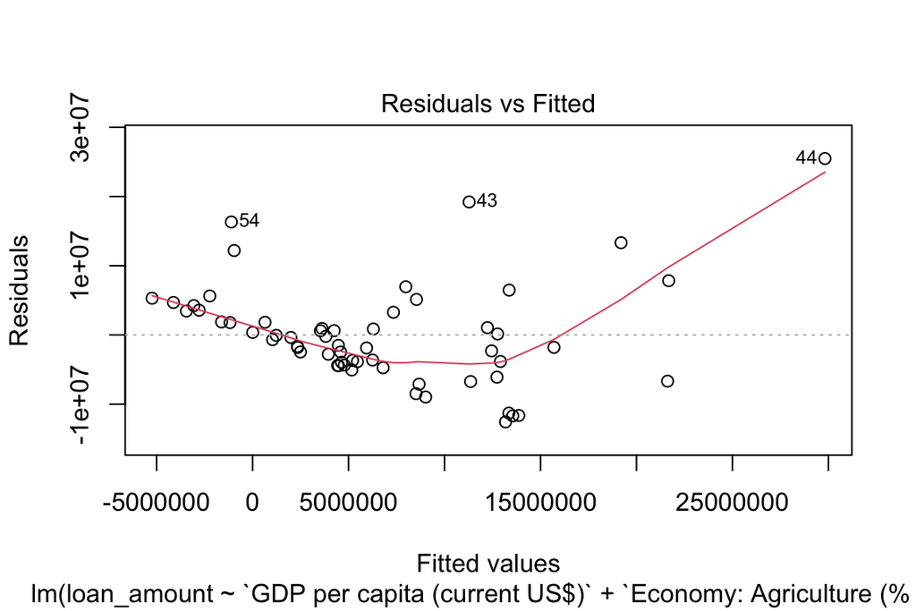

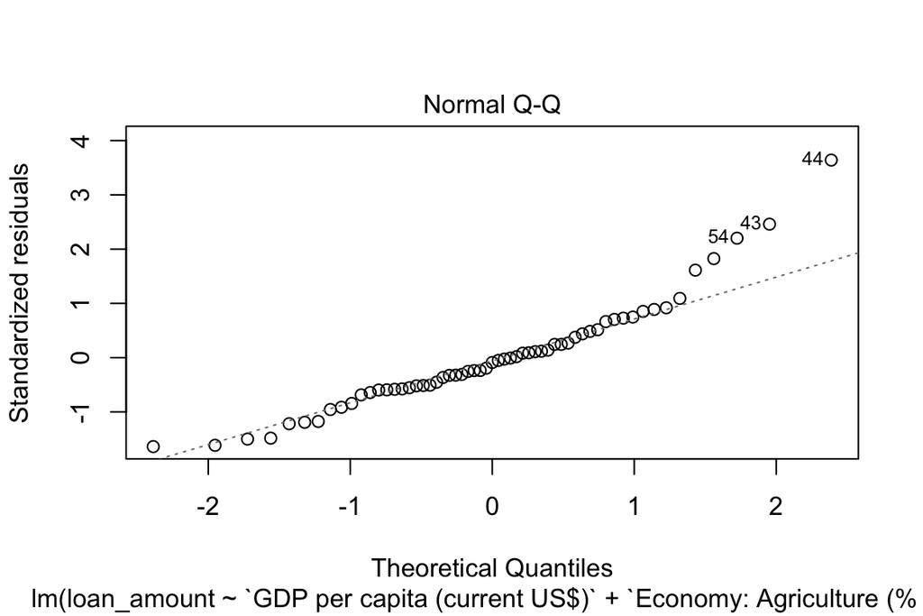

```r
plot(regkivareduced, 1:2)
```

```r
merged2[43, 37]
```

```
## [1] "Peru"
```

```r
merged2[44, 37]
```

```
## [1] "Philippines"
```

```r
merged2 %>% arrange(-loan_amount) %>% select(country, loan_amount)
```

```
##                             country loan_amount
## 1                       Philippines    55301250
## 2                             Kenya    32520075
## 3                              Peru    30493725
## 4                          Paraguay    29514025
## 5                          Cambodia    19841325
## 6                            Uganda    15209525
## 7                           Ecuador    14946950
## 8                        Tajikistan    14941875
## 9                          Colombia    13906275
## 10                      El Salvador    13663125
## 11                         Pakistan    13285075
## 12                          Armenia    12906725
## 13                        Guatemala    11233900
## 14                          Lebanon    10616675
```

[output cut: 45 more lines]

```r
merged2[54,37]
```

```
## [1] "Uganda"
```

By comparing Uganda and countries that have similar loan_amounts, we see that Uganda spends less on agriculture, and much more funds on education, which is not covered by the variables in the model index. By looking at the uses of education sector funding, we see that the fundings cover school tuition, and this is not measured by the model, which could be a limitation.

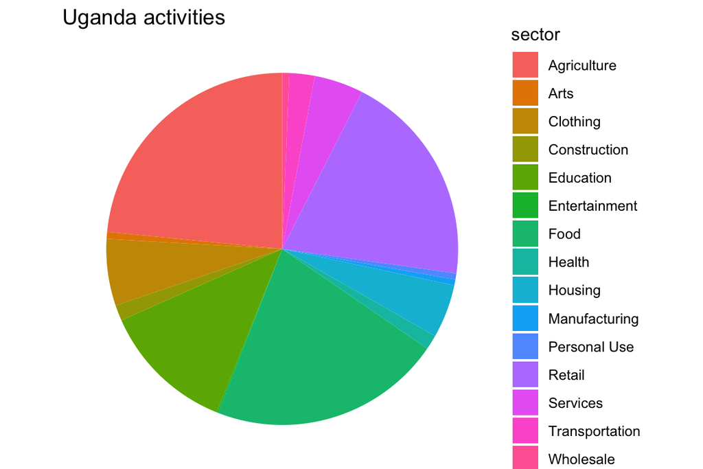

```r
Uganda = loans %>% filter(country == "Uganda") %>%
group_by(sector) %>% summarise(n= sum(loan_amount)) %>% arrange(-n)

ggplot(Uganda, aes(x = "", y = n, fill = sector)) +
  geom_bar(stat = "identity", width = 1) +
  coord_polar("y", start = 0) +
  theme_void() +
  labs(fill = "sector", title = "Uganda activities")
```

```r
UgandaEducation = loans %>% filter(country == "Uganda", sector == "Education") %>%
  summarise(use= use, n = loan_amount) %>% arrange(-n)

head(UgandaEducation)
```

```
##                                                                                     use
## 1                               To pay school fees and add the balance to her business.
## 2 To pay school fees for her five children and also to support her cocoa farming income
## 3                                                                        To pay tuition
## 4                                                         To pay her daughter's tuition
## 5                                                  to pay school fees for his children.
## 6                                                       to pay tuition fees for his son
##      n
## 1 5525
## 2 5000
## 3 4725
## 4 4675
## 5 4650
## 6 4150
```

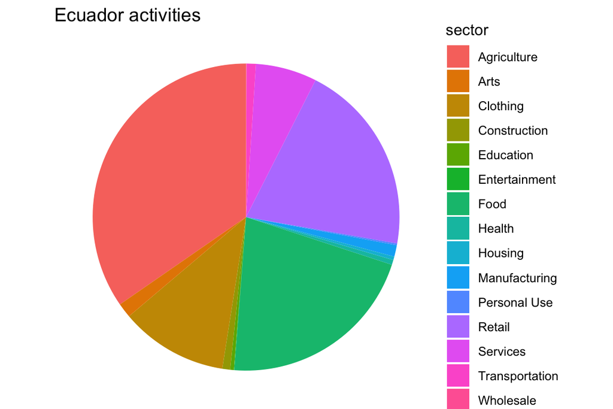

```r
Ecuador = loans %>% filter(country == "Ecuador") %>%
group_by(sector) %>% summarise(n = sum(loan_amount)) %>% arrange(-n)


ggplot(Ecuador, aes(x = "", y = n, fill = sector)) +
  geom_bar(stat = "identity", width = 1) +
  coord_polar("y", start = 0) +
  theme_void() +
  labs(fill = "sector", title = "Ecuador activities")
```

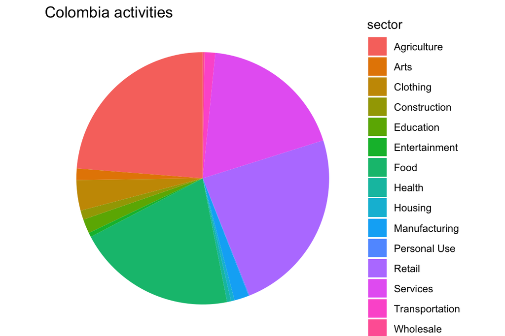

```r
Colombia = loans %>% filter(country == "Colombia") %>%
group_by(sector) %>% summarise(n = sum(loan_amount)) %>% arrange(-n)

ggplot(Colombia, aes(x = "", y = n, fill = sector)) +
  geom_bar(stat = "identity", width = 1) +
  coord_polar("y", start = 0) +
  theme_void() +
  labs(fill = "sector", title = "Colombia activities")
```